# Praca domowa 2

maria eberhardt

## Dane

Dane wykorzystane w Pracy domowej 2 są związane z kampaniami marketingu bezpośredniego portugalskiej instytucji bankowej. Kampanie marketingowe opierały się na rozmowach telefonicznych. Często wymagany był więcej niż jeden kontakt z tym samym klientem, aby uzyskać dostęp do tego, czy produkt (lokata bankowa) zostanie (lub nie) subskrybowany. Opis wszystkich kolumn znajduje się również w pliku `README.md`.

#### Dane klienta banku

| Zmienna | Opis |
| --- | --- |
| **age** | wiek |
| **job** : admin., unknown, unemployed, management, housemaid, entrepreneur, student, blue-collar, self-employed, retired, technician, services | administrator, nieznany, bezrobotny, kierownictwo, pokojówka, przedsiębiorca, student, pracownik fizyczny, samozatrudniony, emeryt, technik, usługi |
| **marital** : married, divorced, single; note: divorced means divorced or widowed) | żonaty/zamężna, rozwiedzion_, kawaler/panna; uwaga: rozwiedzion_ oznacza rozwiedzion_ lub owdowiał_ |
| **education** : unknown, secondary, primary, tertiary | nieznane, średnie, podstawowe, wyższe |
| **default** : yes, no | czy kredyt jest niespłacany : tak, nie |
| **balance** : average yearly balance, in euros | średnie roczne saldo w euro |
| **housing** : has housing loan? yes, no | czy posiada kredyt mieszkaniowy? tak, nie |
| **loan** : has personal loan? yes, no | ma pożyczkę osobistą? tak, nie |

#### Dane związane z ostatnim kontaktem w bieżącej kampanii

| Zmienna | Opis |
| --- | --- |
| **contact** : unknown, telephone, cellular | nieznany, telefon, komórkowy |
| **day** : last contact day of the month | dzień miesiąca ostatniego kontaktu |
| **month** : last contact month of year, jan, feb, mar, …, nov, dec | miesiąc ostatniego kontaktu w roku, styczeń, luty, marzec, …, listopad, grudzień |
| **duration** : last contact duration, in seconds | czas trwania ostatniego kontaktu w sekundach |

## Zadanie 1

Weźmy pod uwagę zawody (`job`) klientów banku. Który zawód zacząco wyróżnia się w posiadaniu kredytu mieszkaniowego lub pożyczki osobistej?

```r
# Tu umieść kod do wygenerowania odpowiedzi do zadania.
loan_counts <- aggregate(loan ~ job, data = df, FUN = function(x) sum(x == "yes"))
colnames(loan_counts) <- c("job", "LoanCount")
print(loan_counts)
```

```
##              job LoanCount
## 1         admin.       991
## 2    blue-collar      1684
## 3   entrepreneur       356
## 4      housemaid       152
## 5     management      1253
## 6        retired       309
## 7  self-employed       229
## 8       services       836
## 9        student        12
## 10    technician      1309
## 11    unemployed       109
## 12       unknown         4
```

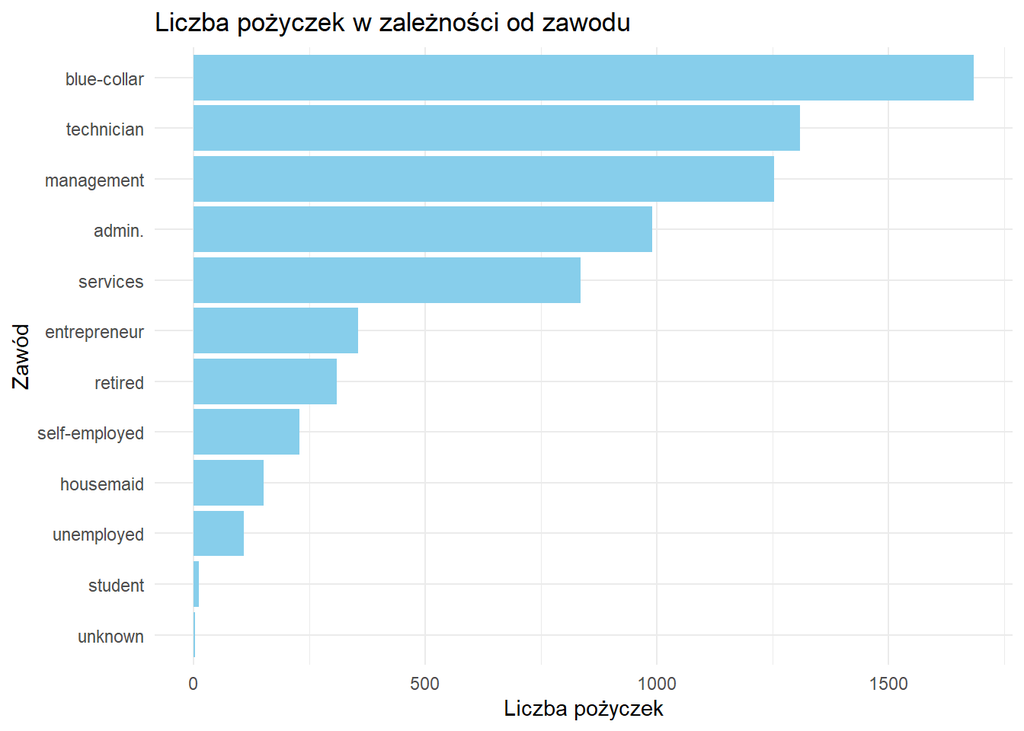

```r
ggplot(loan_counts, aes(x = reorder(job, LoanCount), y = LoanCount)) +
  geom_bar(stat = "identity", fill = "skyblue") +
  coord_flip() +
  labs(title = "Liczba pożyczek w zależności od zawodu",
       x = "Zawód",
       y = "Liczba pożyczek") +
  theme_minimal()
```

**Komentarz:**

## Zadanie 2

Wybierając klientów, którzy mają nieznany sposób kontaktu (`contact`). Jak rozkłada się ich wiek w podziale na status związku?

```r
# Tu umieść kod do wygenerowania odpowiedzi do zadania.
unknown_contact <- df[df$contact == "unknown", ]
age_distribution <- aggregate(age ~ marital, data = unknown_contact, FUN = summary)
print(age_distribution)
```

```
##    marital age.Min. age.1st Qu. age.Median age.Mean age.3rd Qu. age.Max.
## 1 divorced 25.00000    38.00000   45.00000 44.83789    52.00000 61.00000
## 2  married 20.00000    35.00000   41.00000 42.33171    49.00000 61.00000
## 3   single 20.00000    29.00000   33.00000 34.46523    39.00000 60.00000
```

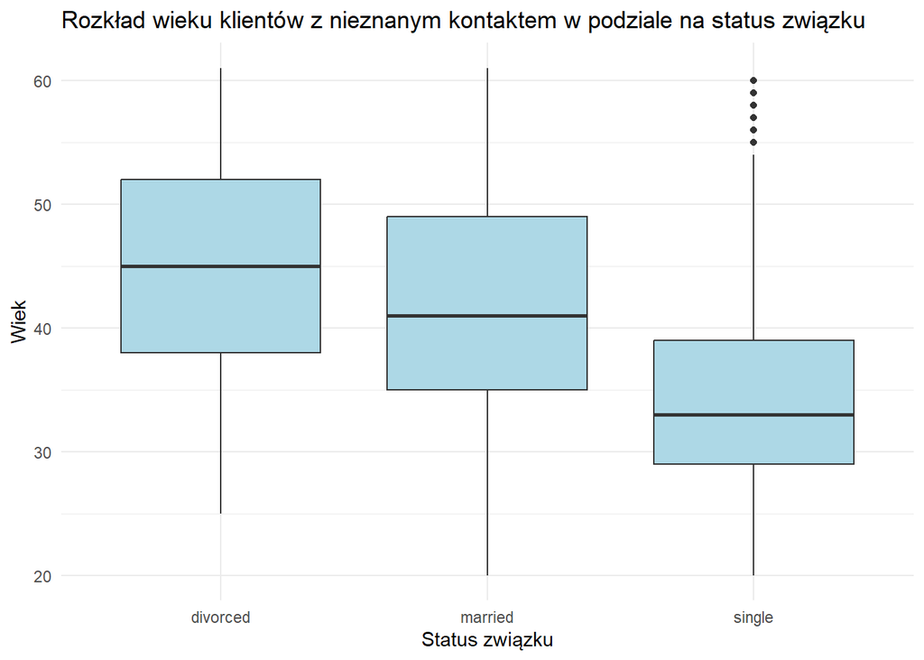

```r
ggplot(unknown_contact, aes(x = marital, y = age)) +
  geom_boxplot(fill = "lightblue") +
  labs(title = "Rozkład wieku klientów z nieznanym kontaktem w podziale na status związku",
       x = "Status związku",
       y = "Wiek") +
  theme_minimal()
```

**Komentarz:**

## Zadanie 3

Jaka jest różnica pomiędzy średnim rocznym saldem w euro w zależności od wykształcenia i tego czy kredyt jest niespłacany?

```r
# Tu umieść kod do wygenerowania odpowiedzi do zadania.
balance_stats <- aggregate(balance ~ education + loan, data = df, FUN = mean)
colnames(balance_stats) <- c("Education", "Loan", "MeanBalance")
print(balance_stats)
```

```
##   Education Loan MeanBalance
## 1   primary   no   1360.1224
## 2 secondary   no   1254.7335
## 3  tertiary   no   1875.6210
## 4   unknown   no   1589.5661
## 5   primary  yes    629.7119
## 6 secondary  yes    716.3223
## 7  tertiary  yes   1001.7769
## 8   unknown  yes    712.5639
```

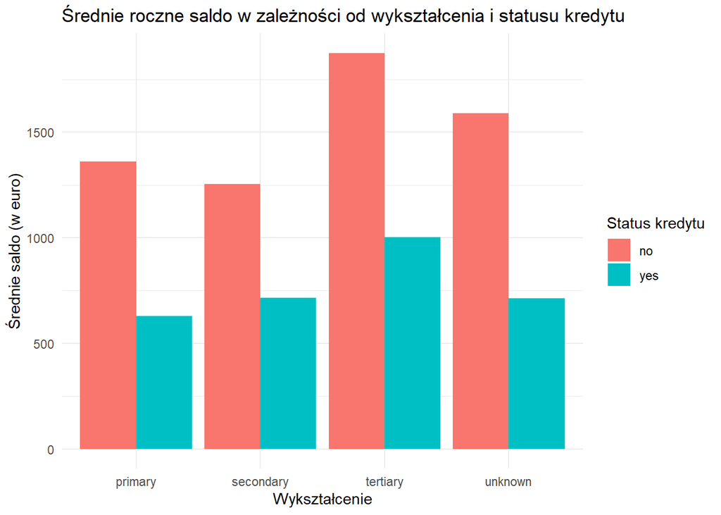

```r
ggplot(balance_stats, aes(x = Education, y = MeanBalance, fill = Loan)) +
  geom_bar(stat = "identity", position = "dodge") +
  labs(title = "Średnie roczne saldo w zależności od wykształcenia i statusu kredytu",
       x = "Wykształcenie",
       y = "Średnie saldo (w euro)",
       fill = "Status kredytu") +
  theme_minimal()
```

**Komentarz:**

## Zadanie 4

Czy dzień i miesiąc kontaktu z klientem ma wpływ na średni czas trwania rozmowy w stosunku do średniego czasu trwania rozmowy?

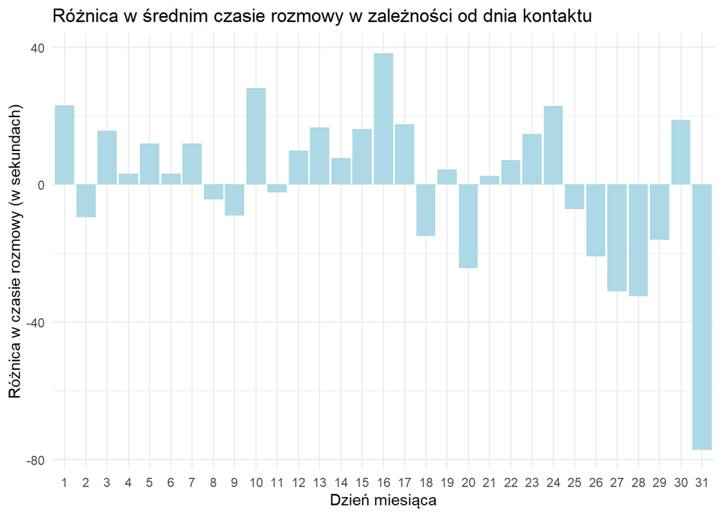

```r
# Tu umieść kod do wygenerowania odpowiedzi do zadania.
overall_mean_duration <- mean(df$duration)
day_mean <- aggregate(duration ~ day, data = df, FUN = mean)
month_mean <- aggregate(duration ~ month, data = df, FUN = mean)
day_mean$Difference <- day_mean$duration - overall_mean_duration
month_mean$Difference <- month_mean$duration - overall_mean_duration

ggplot(day_mean, aes(x = factor(day), y = Difference)) +
  geom_bar(stat = "identity", fill = "lightblue") +
  labs(title = "Różnica w średnim czasie rozmowy w zależności od dnia kontaktu",
       x = "Dzień miesiąca",
       y = "Różnica w czasie rozmowy (w sekundach)") +
  theme_minimal()
```

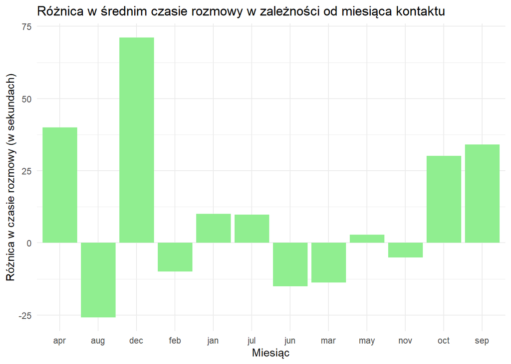

```r
ggplot(month_mean, aes(x = factor(month), y = Difference)) +
  geom_bar(stat = "identity", fill = "lightgreen") +
  labs(title = "Różnica w średnim czasie rozmowy w zależności od miesiąca kontaktu",
       x = "Miesiąc",
       y = "Różnica w czasie rozmowy (w sekundach)") +
  theme_minimal()
```

**Komentarz:**

## Zadanie 5

Czy jest zależnośc pomiędzy wiekiem klientów a ich średnim rocznym saldzie w euro w podziale na stopień wykształcenia?

```r
# Tu umieść kod do wygenerowania odpowiedzi do zadania.
#zad5 zahashtagowany bo bardzo dlugo sie wywolywal

 #ggplot(df, aes(x = age, y = balance, color = education)) +
 # geom_point(alpha = 0.6) +  # Punkty na wykresie
 # geom_smooth(method = "lm", se = FALSE) +  # Regresja liniowa
 # labs(title = "Zależność między wiekiem a średnim rocznym saldem w euro w podziale na stopień wykształcenia",
 #    x = "Wiek",
 #      y = "Średnie roczne saldo (w euro)",
 #     color = "Wykształcenie") +
 # theme_minimal()
```

**Komentarz:**

## Zadanie 6

Rozważmy osoby, które są bezrobotne albo ich zawód jest nieznany. Czy procent osób, które są bezrobotne i nie spłacają kredytu jest większy od procenta osób o nieznanym zawodzie i nie spłacanym kredycie? Jaki typ kredytu jest (przez te osoby) najczęściej niespłacany?

```r
# Tu umieść kod do wygenerowania odpowiedzi do zadania.
filtered_data <- df[df$occupation %in% c("unemployed", "unknown"), ]
unemployed_data <- filtered_data[filtered_data$occupation == "unemployed", ]
unknown_data <- filtered_data[filtered_data$occupation == "unknown", ]
unemployed_loan <- nrow(unemployed_data[unemployed_data$loan == "yes", ])
unknown_loan <- nrow(unknown_data[unknown_data$Loan == "yes", ])
percent_unemployed <- (unemployed_loan / nrow(unemployed_data)) * 100
percent_unknown <- (unknown_loan / nrow(unknown_data)) * 100

comparison <- ifelse(percent_unemployed > percent_unknown,
                     "Bezrobotni mają większy procent niespłacanych kredytów",
                     "Osoby o nieznanym zawodzie mają większy procent niespłacanych kredytów")
comparison
```

```
## [1] NA
```

**Komentarz:**